# `Boots` Package Review

CPT James Gallagher

March 12, 2018

## Overview

CPT Small presented a Shiny App geared towards helping analysts better forecast US Troop “Boots-on-the-Ground” based on open source data provided from the Defense Manpower Data Center. He outlined 9 features that this app should accomplish as part of routine use. These features and the analysis of these features are outlined below:

## Feature Review

- **Forecast** - This portion of the app is done behind the scenes. However, when the sliders are moved or a different country/branch of service is selected, the visible plots do regenerate without any errors appearing in either the app or the console.
- **Provide Values** - The plots and report tabs regenerate with new results when the inputs are changed. Assuming users of the report are familiar with what the outputs are supposed to be and what those outputs mean, then the outputs will be useful. However, for a new user to this type of forecasting, some of the outputs seem to be missing context to help the user understand the meaning of the charts. For example, the residual plots are calculated and presented.

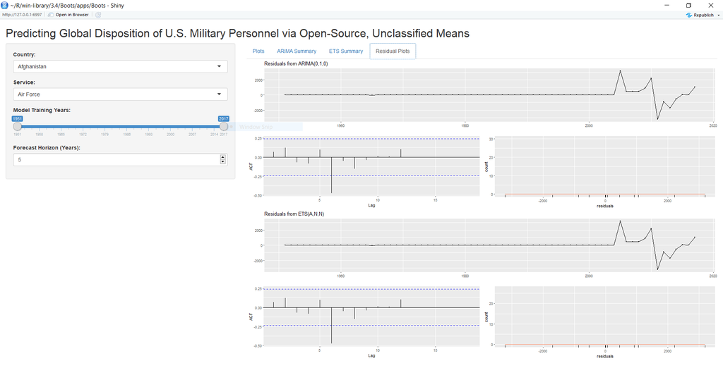

  However, no context is provided to help beginner users understand what these residuals mean or how they should be incorproated into analysis.
- **Plot Forecasts** - The forecast plots are recalculated and presented each time an input updates. The plots match the output provided in the report tabs, so the plots seem to be accurate. Again, no errors or warnings appear when the plots are generated.
- **Order Data** - This is another feature that is completed behind the scenes in the App. When comparing the generated plots to the dataset contained in the “data” folder for a few data situations, such as Soldiers in Afghanistan.

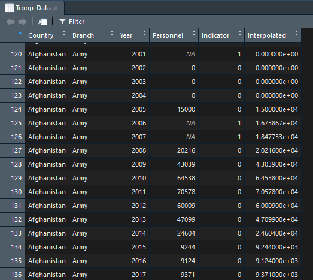

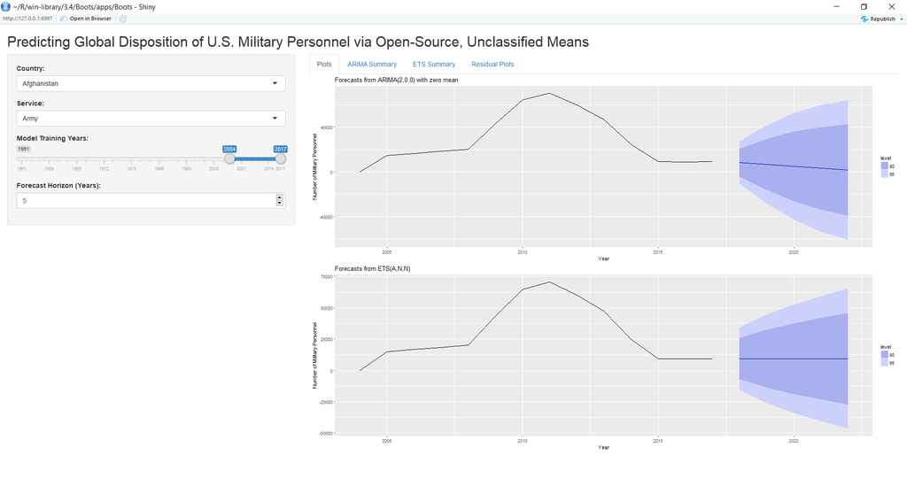

  The table is presented sequentially and the plot mirrors the table’s output. Therefore, this feature appears to be working as intended.

**Convert Data** - The report outputs on the ARIMA summary and ETS Summary looks properly formatted relative to what the regular output should be. Additionally, these outputs match the plots on the first tab. Therefore, the objects appear to be calculating appropriately.

**Group Data** - Continuing from the previous feature, the data presented in the plots mirror identically the specific situations provided above. Therefore, the plots appear to be generating forecast objects only on the selected groups and not including other irrelevant information. Therefore, this function appears to be woring as intended as well.

**Tidy the Data** - The dataset provided in the package comes tidied according to the “Tidyverse” rules. Therefore this feature is complete. However, it is unclear if this shiny app will conducts this tidying if new data is presented.

**Fill Missing Data** - The dataset provides an imputed number column. This number on first glance appears to be a linear imputation from the two most recent encompassing years (i.e. if 1998 is missing, then that troop data is linearly imputed from 1997 and 1999). However, as with the previous feature, while present in the given data set, the ability to provide new data and confirm that it recalculates new imputed values is unclear.

**Assess Accuracy** - The model outputs are provided to allow users to identify which model provides the best response based on the data inputs. This part also exhibits areas that require expert knowledge to use. Novice or beginner users will have a difficult time identifying which model output is better suited for their situation.

## Overall Review

Overall, this app does what the proposal indicates. The app calculates a forecast object and allows the user to select which country and which branch of US Service for forecasting. Additionally, it provides the outputs in easy to read plots that match across the different tabs. Additionally, the output seem correctly calculated relative to what an untrained eye would expect the outputs to look like. However, this app does have a shortcoming of not having immediate use for a new or beginner user. Users will have to do some external research to have a useable understanding of what the outputs are and what they are telling the user.

## Result

**48** (if no gradation allowed, then **50**) - This app performs as required. There are no warnings or errors as the user generates outputs. The inputs are easy to use and understand what they are changing on the data set. The plots are easy to read and match across tabs. My only improvement would be to include a front page that highlights what the app is supposed to do, and how each tab in the app helps accomplish that goal. This front page could also explain some of the finer detailed items like which metric is best used for selecting a model or explaining the residuals and how the residuals might impact model selection or outputs. Otherwise, this app meets the requirements and could be published immediately to an audience of analysts who are familiar with these model types and can use their expertise immediately.